# Praktikum 5 Analisis Regresi

Restu Ramadhani_M0401241047

2026-06-17

# Library

```r
library(readxl)
library(GGally)
library(corrplot)
library(dplyr)
library(car)
```

# Data

```r
data <- read_excel("C:/Downloads/Data Analisis Regresi.xlsx")

head(data)
```

```
## # A tibble: 6 × 8
##   `Kabupaten/Kota` `Jumlah Penyakit DBD` `Indeks Pembangunan Manusia`
##   <chr>                            <dbl>                        <dbl>
## 1 Pacitan                            295                         70.2
## 2 Ponorogo                           308                         72.6
## 3 Trenggalek                         268                         71.3
## 4 Tulungagung                        410                         74.1
## 5 Blitar                             351                         72.2
## 6 Kediri                             365                         74.2
## # ℹ 5 more variables: `Persentase Penduduk Miskin` <dbl>,
## #   `Persentase RT Terhadap Sanitasi Layak` <dbl>,
## #   `Persentase RT terhadap Sumber Air Minum Layak` <dbl>,
## #   `Persentase Memiliki Jaminan Kesehatan` <dbl>, `Kepadatan Penduduk` <dbl>
```

```r
str(data)
```

```
## tibble [38 × 8] (S3: tbl_df/tbl/data.frame)
##  $ Kabupaten/Kota                               : chr [1:38] "Pacitan" "Ponorogo" "Trenggalek" "Tulungagung" ...
##  $ Jumlah Penyakit DBD                          : num [1:38] 295 308 268 410 351 ...
##  $ Indeks Pembangunan Manusia                   : num [1:38] 70.2 72.6 71.3 74.1 72.2 ...
##  $ Persentase Penduduk Miskin                   : num [1:38] 13.8 9.32 10.96 6.71 8.71 ...
##  $ Persentase RT Terhadap Sanitasi Layak        : num [1:38] 72.6 86.8 79.3 83.6 80.1 ...
##  $ Persentase RT terhadap Sumber Air Minum Layak: num [1:38] 84 91.5 81.2 96.4 96.4 ...
##  $ Persentase Memiliki Jaminan Kesehatan        : num [1:38] 45.2 57.8 51.9 48.3 44.1 ...
##  $ Kepadatan Penduduk                           : num [1:38] 414 680 592 966 711 ...
```

```r
summary(data)
```

```
##    Kabupaten/Kota Jumlah Penyakit DBD Indeks Pembangunan Manusia
##  Length   :38     Min.   :  57.0      Min.   :65.44
##  N.unique :38     1st Qu.: 220.0      1st Qu.:70.34
##  N.blank  : 0     Median : 300.5      Median :73.33
##  Min.nchar: 5     Mean   : 346.3      Mean   :74.00
##  Max.nchar:16     3rd Qu.: 396.5      3rd Qu.:77.23
##                   Max.   :1255.0      Max.   :83.38
##  Persentase Penduduk Miskin Persentase RT Terhadap Sanitasi Layak
##  Min.   : 3.790             Min.   :51.64
##  1st Qu.: 7.265             1st Qu.:78.37
##  Median : 9.630             Median :83.93
##  Mean   :10.326             Mean   :82.16
##  3rd Qu.:12.450             3rd Qu.:90.57
##  Max.   :21.610             Max.   :96.41
##  Persentase RT terhadap Sumber Air Minum Layak
##  Min.   : 78.56
##  1st Qu.: 94.65
##  Median : 96.38
##  Mean   : 95.36
##  3rd Qu.: 98.67
##  Max.   :100.00
##  Persentase Memiliki Jaminan Kesehatan Kepadatan Penduduk
##  Min.   :21.45                         Min.   : 414.0
##  1st Qu.:52.96                         1st Qu.: 643.0
##  Median :65.22                         Median : 913.5
##  Mean   :69.00                         Mean   :2071.1
##  3rd Qu.:91.40                         3rd Qu.:2479.8
##  Max.   :99.27                         Max.   :8595.0
```

Data yang digunakan adalah data dari 38 Kabupaten/Kota di Jawa Timur Tahun 2022 dengan:

- Y = Jumlah Penyakit DBD
- X1 = Indeks Pembangunan Manusia (IPM)
- X2 = Persentase Penduduk Miskin (PM)
- X3 = Persentase RT Terhadap Sanitasi Layak (RTSL)
- X4 = Persentase RT Terhadap Sumber Air Minum Layak (RTAML)
- X5 = Persentase Memiliki Jaminan Kesehatan (JK)
- X6 = Kepadatan Penduduk (KP)

Untuk mempermudah dalam komputasi, karena peubah Kabupaten/Kota tidak digunakan, maka dapat dihapus.

```r
dt <- data %>%
  select(-`Kabupaten/Kota`)
```

# Eksplorasi Data

## Histogram

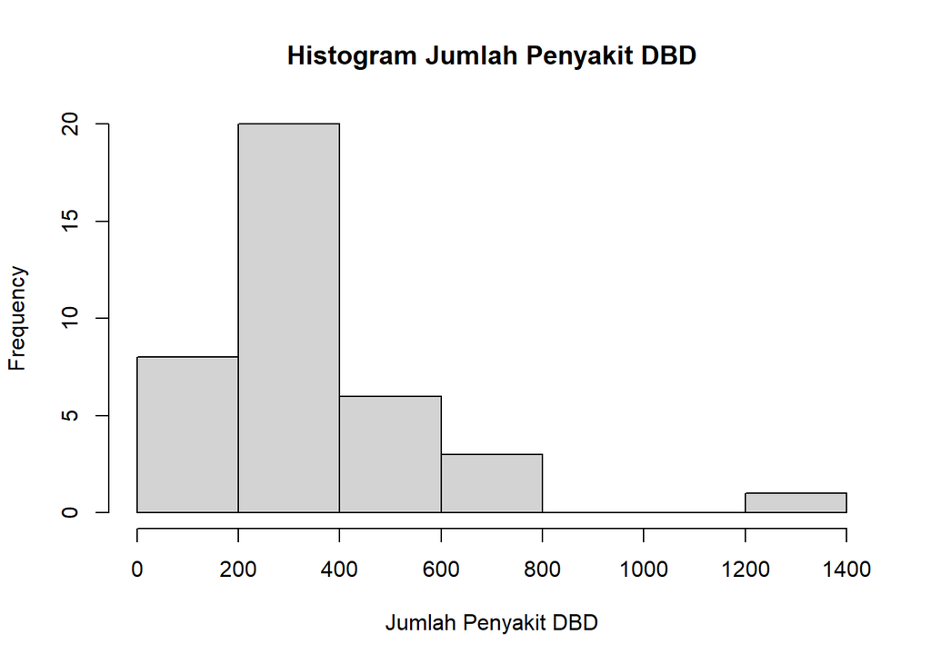

```r
hist(
  dt$`Jumlah Penyakit DBD`,
  main = "Histogram Jumlah Penyakit DBD",
  xlab = "Jumlah Penyakit DBD"
)
```

## Boxplot

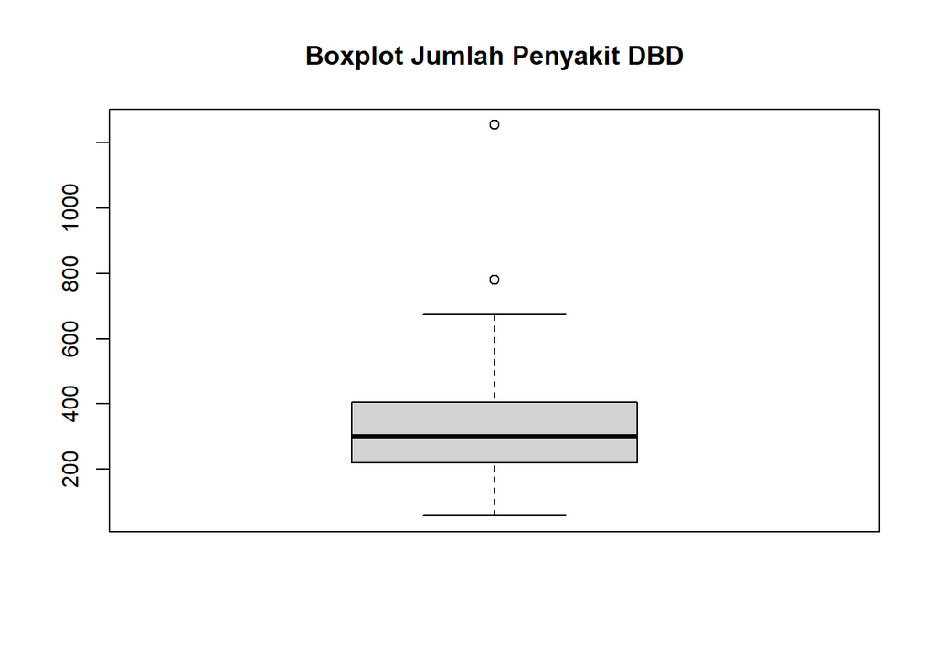

```r
boxplot(
  dt$`Jumlah Penyakit DBD`,
  main = "Boxplot Jumlah Penyakit DBD"
)
```

## Scatterplot Matrix

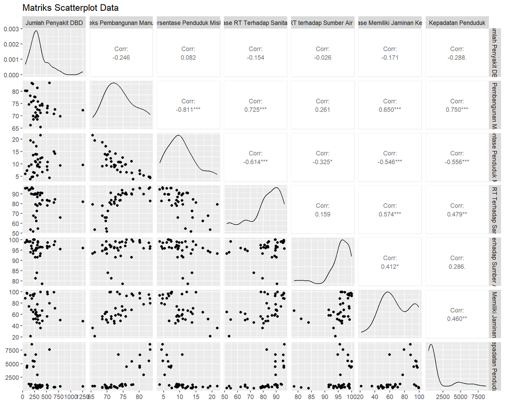

```r
ggpairs(
  dt,
  upper = list(
    continuous = wrap("cor", size = 3)
  ),
  title = "Matriks Scatterplot Data"
)
```

## Matriks Korelasi

```r
cor_matrix <- cor(dt, use = "complete.obs")
round(cor_matrix, 2)
```

```
##                                               Jumlah Penyakit DBD
## Jumlah Penyakit DBD                                          1.00
## Indeks Pembangunan Manusia                                  -0.25
## Persentase Penduduk Miskin                                   0.08
## Persentase RT Terhadap Sanitasi Layak                       -0.15
## Persentase RT terhadap Sumber Air Minum Layak               -0.03
## Persentase Memiliki Jaminan Kesehatan                       -0.17
## Kepadatan Penduduk                                          -0.29
##                                               Indeks Pembangunan Manusia
## Jumlah Penyakit DBD                                                -0.25
## Indeks Pembangunan Manusia                                          1.00
## Persentase Penduduk Miskin                                         -0.81
## Persentase RT Terhadap Sanitasi Layak                               0.73
## Persentase RT terhadap Sumber Air Minum Layak                       0.26
## Persentase Memiliki Jaminan Kesehatan                               0.65
## Kepadatan Penduduk                                                  0.75
##                                               Persentase Penduduk Miskin
## Jumlah Penyakit DBD                                                 0.08
## Indeks Pembangunan Manusia                                         -0.81
## Persentase Penduduk Miskin                                          1.00
## Persentase RT Terhadap Sanitasi Layak                              -0.61
## Persentase RT terhadap Sumber Air Minum Layak                      -0.32
## Persentase Memiliki Jaminan Kesehatan                              -0.55
## Kepadatan Penduduk                                                 -0.56
##                                               Persentase RT Terhadap Sanitasi Layak
## Jumlah Penyakit DBD                                                           -0.15
## Indeks Pembangunan Manusia                                                     0.73
## Persentase Penduduk Miskin                                                    -0.61
## Persentase RT Terhadap Sanitasi Layak                                          1.00
## Persentase RT terhadap Sumber Air Minum Layak                                  0.16
## Persentase Memiliki Jaminan Kesehatan                                          0.57
## Kepadatan Penduduk                                                             0.48
##                                               Persentase RT terhadap Sumber Air Minum Layak
## Jumlah Penyakit DBD                                                                   -0.03
## Indeks Pembangunan Manusia                                                             0.26
## Persentase Penduduk Miskin                                                            -0.32
## Persentase RT Terhadap Sanitasi Layak                                                  0.16
## Persentase RT terhadap Sumber Air Minum Layak                                          1.00
## Persentase Memiliki Jaminan Kesehatan                                                  0.41
## Kepadatan Penduduk                                                                     0.29
##                                               Persentase Memiliki Jaminan Kesehatan
## Jumlah Penyakit DBD                                                           -0.17
## Indeks Pembangunan Manusia                                                     0.65
## Persentase Penduduk Miskin                                                    -0.55
## Persentase RT Terhadap Sanitasi Layak                                          0.57
## Persentase RT terhadap Sumber Air Minum Layak                                  0.41
## Persentase Memiliki Jaminan Kesehatan                                          1.00
## Kepadatan Penduduk                                                             0.46
##                                               Kepadatan Penduduk
## Jumlah Penyakit DBD                                        -0.29
## Indeks Pembangunan Manusia                                  0.75
## Persentase Penduduk Miskin                                 -0.56
## Persentase RT Terhadap Sanitasi Layak                       0.48
## Persentase RT terhadap Sumber Air Minum Layak               0.29
## Persentase Memiliki Jaminan Kesehatan                       0.46
## Kepadatan Penduduk                                          1.00
```

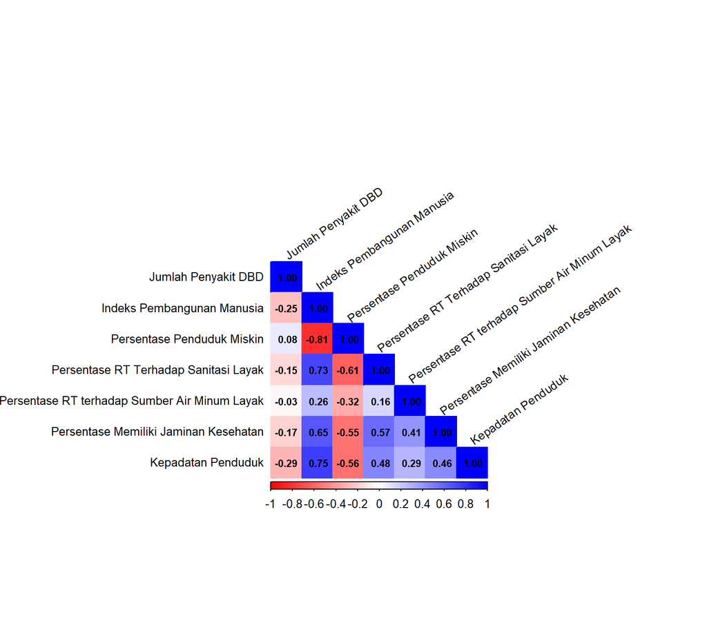

```r
corrplot(
  cor_matrix,
  method = "color",
  type = "lower",
  col = colorRampPalette(
    c("red","white","blue")
  )(200),
  addCoef.col = "black",
  tl.col = "black",
  tl.srt = 35,
  tl.cex = 0.8,
  number.cex = 0.7
)
```

Hasil matriks scatter plot dan korelasi menunjukkan bahwa peubah respon Jumlah Penyakit DBD memiliki hubungan positif dengan Persentase Penduduk Miskin (0,08), serta hubungan negatif dengan Indeks Pembangunan Manusia (IPM) (-0,25), Persentase RT terhadap Sanitasi Layak (-0,15), Persentase RT terhadap Sumber Air Minum Layak (-0,03), Persentase Memiliki Jaminan Kesehatan (-0,17), dan Kepadatan Penduduk (-0,29). Namun, berdasarkan nilai koefisien korelasi yang relatif kecil, hubungan antara Jumlah Penyakit DBD dengan seluruh peubah penjelas cenderung lemah.

Selain itu, terdapat beberapa korelasi yang cukup tinggi antar peubah penjelas, baik positif maupun negatif. Beberapa di antaranya adalah: 1. IPM dan Persentase Penduduk Miskin memiliki korelasi negatif yang sangat kuat sebesar -0,81. 2. IPM dan Persentase RT terhadap Sanitasi Layak memiliki korelasi positif kuat sebesar 0,73. 3. IPM dan Kepadatan Penduduk memiliki korelasi positif kuat sebesar 0,75. 4. Persentase Penduduk Miskin dan Persentase RT terhadap Sanitasi Layak memiliki korelasi negatif kuat sebesar -0,61. 5. IPM dan Persentase Memiliki Jaminan Kesehatan memiliki korelasi positif sebesar 0,65. 6. Persentase Penduduk Miskin dan Persentase Memiliki Jaminan Kesehatan memiliki korelasi negatif sebesar -0,55. 7. Persentase Penduduk Miskin dan Kepadatan Penduduk memiliki korelasi negatif sebesar -0,56. 8. Persentase RT terhadap Sanitasi Layak dan Persentase Memiliki Jaminan Kesehatan memiliki korelasi positif sebesar 0,57.

Korelasi yang cukup tinggi antar beberapa peubah penjelas tersebut mengindikasikan adanya potensi multikolinearitas dalam data. Kondisi ini dapat menyebabkan ketidakstabilan estimasi parameter regresi serta menurunkan kemampuan model dalam mengidentifikasi pengaruh masing-masing peubah penjelas secara akurat. Oleh karena itu, diperlukan pemeriksaan lebih lanjut, misalnya menggunakan Variance Inflation Factor (VIF) atau metode penanganan multikolinearitas lainnya.

# Pemodelan Regresi Linear Berganda

## Perhitungan Manual (Matriks)

Perhitungan nilai $\hat{\beta}$ secara matriks dapat dilakukan dengan rumus berikut.

$$\hat{\beta} = (X'X)^{-1}
X'y$$
### Membentuk Matriks X dan Y

```r
n <- nrow(dt)

x0 <- rep(1,n)

X <- cbind(
  x0,
  dt$`Indeks Pembangunan Manusia`,
  dt$`Persentase Penduduk Miskin`,
  dt$`Persentase RT Terhadap Sanitasi Layak`,
  dt$`Persentase RT terhadap Sumber Air Minum Layak`,
  dt$`Persentase Memiliki Jaminan Kesehatan`,
  dt$`Kepadatan Penduduk`
)

X <- as.matrix(X)

Y <- dt$`Jumlah Penyakit DBD`
```

### Menghitung Dugaan Parameter

```r
beta_duga <- solve(t(X)%*%X)%*%t(X)%*%Y

beta_duga
```

```
##             [,1]
## x0 1488.56857280
##     -14.96728603
##     -15.65147704
##       0.38270872
##       1.91090428
##      -0.65696872
##      -0.01997539
```

Hasil tersebut menjelaskan bahwa persamaan yang terbentuk adalah
$$\hat{JPD}=1488.57-14.97IPM-15.65PM+0.38RTSL+1.91RTAML−0,66JK-0,02KP$$
Selang kepercayaan dan pengujian signifikansi setiap parameter dapat dilakukan dengan menghitung keragaman tiap dugaan parameter. Secara umum, nilai ragam dugaan parameter $\hat{\beta}_j$ dapat dihitung melalui rumus berikut.

$$Var(\hat{\beta}_j) = \hat{\sigma}^2
C_{jj}$$
Dengan matriks $C$ adalah matriks $(X'X)^{-1}$

Unsur diagonal dari matriks $C$ dapat digunakan untuk menghitung nilai galat baku dari setiap dugaan parameter. Galat baku ini dapat digunakan untuk menghitung selang kepercayaan dari dugaan yang dihasilkan.

$$SE(\hat{\beta}_j) =
\sqrt{Var(\hat{\beta}_j)} = \sqrt{\sigma^2 C_{jj}} =
\hat{\sigma}\sqrt{c_{ii}}$$
### Persamaan Regresi

```r
round(beta_duga,4)
```

```
##         [,1]
## x0 1488.5686
##     -14.9673
##     -15.6515
##       0.3827
##       1.9109
##      -0.6570
##      -0.0200
```

## Selang Kepercayaan Parameter

```r
Yhat <- X %*% beta_duga

residual <- Y - Yhat

n <- nrow(X)
p <- ncol(X)

KTG <- sum(residual^2)/(n-p)
KTG
```

```
## [1] 52397.58
```

### Matriks C

```r
Cmat <- solve(t(X)%*%X)

Cmat
```

```
##               x0
## x0 63.2818566764 -6.075965e-01 -3.801808e-01  1.015427e-02 -1.936190e-01
##    -0.6075964618  8.080801e-03  3.673916e-03 -6.675111e-04  6.275033e-04
##    -0.3801807796  3.673916e-03  4.668288e-03  8.595441e-05  6.140949e-04
##     0.0101542715 -6.675111e-04  8.595441e-05  4.015840e-04  8.644096e-05
##    -0.1936190032  6.275033e-04  6.140949e-04  8.644096e-05  1.533730e-03
##     0.0329946681 -3.051797e-04 -4.315827e-05 -4.871844e-05 -1.573491e-04
##     0.0004769571 -5.937731e-06 -1.233722e-06  2.329522e-07 -8.021793e-07
##
## x0  3.299467e-02  4.769571e-04
##    -3.051797e-04 -5.937731e-06
##    -4.315827e-05 -1.233722e-06
##    -4.871844e-05  2.329522e-07
##    -1.573491e-04 -8.021793e-07
##     1.277645e-04  1.096036e-07
##     1.096036e-07  1.206973e-08
```

Misalkan akan dihitung selang kepercayaan untuk parameter β₂ (Persentase Penduduk Miskin).

### Standar Error β₂

```r
se_b2 <- sqrt(KTG*Cmat[3,3])
se_b2
```

```
## [1] 15.63992
```

### Selang Kepercayaan 95%

```r
alpha <- 0.05

t_tabel <- qt(
  1-alpha/2,
  df=n-p
)

bb_b2 <- beta_duga[3,1] -
  t_tabel*se_b2

ba_b2 <- beta_duga[3,1] +
  t_tabel*se_b2

bb_b2
```

```
##
## -47.5493
```

```r
ba_b2
```

```
##
## 16.24634
```

Sehingga selang kepercayaan untuk β₂ adalah:

Dengan demikian, kita dapat ketahui selang kepercayaan untuk $\hat{\beta}_2$ sebagai berikut.
$$-47.5493 <\hat{\beta}_2< 16.24634$$
Pada kasus selang kepercayaan $\hat{\beta}_2$ di atas, didapati bahwa dugaan parameter berada dalam rentang yang mengandung nilai 0. Dengan demikian, dapat dimaknai bahwa diduga nilai parameter $\hat{\beta}_2$ bernilai 0 atau tidak signifikan dalam taraf nyata 5%.

# Pemodelan Menggunakan Fungsi lm()

```r
model1 <- lm(`Jumlah Penyakit DBD` ~ ., data = dt)
summary(model1)
```

```
##
## Call:
## lm(formula = `Jumlah Penyakit DBD` ~ ., data = dt)
##
## Residuals:
##     Min      1Q  Median      3Q     Max
## -248.22 -118.92  -38.49   35.63  829.11
##
## Coefficients:
##                                                   Estimate Std. Error t value
## (Intercept)                                     1488.56857 1820.93820   0.817
## `Indeks Pembangunan Manusia`                     -14.96729   20.57704  -0.727
## `Persentase Penduduk Miskin`                     -15.65148   15.63992  -1.001
## `Persentase RT Terhadap Sanitasi Layak`            0.38271    4.58716   0.083
## `Persentase RT terhadap Sumber Air Minum Layak`    1.91090    8.96458   0.213
## `Persentase Memiliki Jaminan Kesehatan`           -0.65697    2.58738  -0.254
## `Kepadatan Penduduk`                              -0.01998    0.02515  -0.794
##                                                 Pr(>|t|)
## (Intercept)                                        0.420
## `Indeks Pembangunan Manusia`                       0.472
## `Persentase Penduduk Miskin`                       0.325
## `Persentase RT Terhadap Sanitasi Layak`            0.934
## `Persentase RT terhadap Sumber Air Minum Layak`    0.833
## `Persentase Memiliki Jaminan Kesehatan`            0.801
## `Kepadatan Penduduk`                               0.433
##
## Residual standard error: 228.9 on 31 degrees of freedom
## Multiple R-squared:   0.12,  Adjusted R-squared:  -0.05032
## F-statistic: 0.7046 on 6 and 31 DF,  p-value: 0.6482
```

Dugaan parameter model secara matriks dan fungsi menghasilkan angka yang sama, sehingga perhitungan matriks memang sudah tepat. Berdasarkan ringkasan model regresi untuk variabel respon Jumlah Penyakit DBD, dapat dilihat bahwa seluruh peubah penjelas, yaitu Indeks Pembangunan Manusia (IPM), Persentase Penduduk Miskin, Persentase RT terhadap Sanitasi Layak, Persentase RT terhadap Sumber Air Minum Layak, Persentase Memiliki Jaminan Kesehatan, dan Kepadatan Penduduk, tidak ada yang signifikan secara individual pada taraf nyata 5%. Hal ini menunjukkan bahwa secara parsial masing-masing variabel belum mampu menjelaskan variasi jumlah kasus DBD secara signifikan dalam model. Secara umum, hasil ini mengindikasikan bahwa model yang dibentuk kurang baik dalam menjelaskan variasi jumlah kasus DBD. Kondisi ini dapat disebabkan oleh kemungkinan adanya pelanggaran asumsi regresi maupun adanya multikolinearitas antar variabel penjelas.

# Pemeriksaan Multikolinearitas

## Variance Inflation Factor (VIF)

```r
vif_model1 <- vif(model1)

vif_model1
```

```
##                    `Indeks Pembangunan Manusia`
##                                        6.691048
##                    `Persentase Penduduk Miskin`
##                                        3.149630
##         `Persentase RT Terhadap Sanitasi Layak`
##                                        2.267094
## `Persentase RT terhadap Sumber Air Minum Layak`
##                                        1.320882
##         `Persentase Memiliki Jaminan Kesehatan`
##                                        2.065353
##                            `Kepadatan Penduduk`
##                                        2.460525
```

```r
data.frame(
  Variabel = names(vif_model1),
  VIF = round(vif_model1,3)
)
```

```
##                                                                                        Variabel
## `Indeks Pembangunan Manusia`                                       `Indeks Pembangunan Manusia`
## `Persentase Penduduk Miskin`                                       `Persentase Penduduk Miskin`
## `Persentase RT Terhadap Sanitasi Layak`                 `Persentase RT Terhadap Sanitasi Layak`
## `Persentase RT terhadap Sumber Air Minum Layak` `Persentase RT terhadap Sumber Air Minum Layak`
## `Persentase Memiliki Jaminan Kesehatan`                 `Persentase Memiliki Jaminan Kesehatan`
## `Kepadatan Penduduk`                                                       `Kepadatan Penduduk`
##                                                   VIF
## `Indeks Pembangunan Manusia`                    6.691
## `Persentase Penduduk Miskin`                    3.150
## `Persentase RT Terhadap Sanitasi Layak`         2.267
## `Persentase RT terhadap Sumber Air Minum Layak` 1.321
## `Persentase Memiliki Jaminan Kesehatan`         2.065
## `Kepadatan Penduduk`                            2.461
```

Kriteria umum:

- VIF < 5 : Tidak ada multikolinearitas serius
- 5 ≤ VIF < 10 : Multikolinearitas sedang
- VIF ≥ 10 : Multikolinearitas tinggi

# Uji Hipotesis Kesamaan Parameter Regresi

Hipotesis yang diuji adalah

$$H_0: β1=β2=β3=β4=β5=β6$$
$$H_1: β1≠β2≠β3≠β4≠β5≠β6$$